# Comparison_GO_predictions_Taxus_final_resutls

Thomas Francisco

2024-11-11

The aim of this script is to compare population genomic offset predictions across models and sets of SNPs. It will also produce a map of the genomic offsets described in the paper.

```r
meta_data_pop <- read.csv("C:/Users/tfrancisco/Documents/Thesis/Data/Species/Taxus_baccata/Populations/taxus_sample_29pop.csv",h=T,sep=";",dec=",")

#alphabetic order
meta_data_pop_order <- meta_data_pop[order(meta_data_pop$Population),]
```

# Data

```r
list_models <- c("all","random_same_AF","LC","random_AF_V2","all_outliers")
list_period <- c("present","future_mean")

df_present <- list()
df_future <- list()

# Loop through the models and periods, loading the data and extracting the second column
for (x in 1:length(list_models)) {
  name <- list_models[x]

  for (i in 1:length(list_period)) {
    period <- list_period[i]

    # Load RDA data (standard GO)
    load(paste0("C:/Users/tfrancisco/Documents/Thesis/Results/species/taxus/Genomic_offset/RDA/data/GO_T_Adapcon_Gentree_RDA_", name, "_", period, ".Rdata"))
    df <- get(paste0("GO_T_Adapcon_Gentree_RDA_",name, "_", period))
    temp_df <- data.frame(temp = df[,2]) # Extract the second column
    colnames(temp_df) <- paste0("RDA_",name) # Rename the column

    # Append to the corresponding list based on the period
    if (period == "present") {
      df_present[[length(df_present) + 1]] <- temp_df
    } else if (period == "future_mean") {
      df_future[[length(df_future) + 1]] <- temp_df
    }


    # Load GF GO data
    load(paste0("C:/Users/tfrancisco/Documents/Thesis/Results/species/taxus/Genomic_offset/GF/data/GCMs_separate/GO_T_Adapcon_Gentree_GF_", name, "_", period, ".Rdata"))
    df <- get(paste0("GO_T_Adapcon_Gentree_GF_",name, "_", period))
    temp_df <- data.frame(temp = df[,2]) # Extract the second column
    colnames(temp_df) <- paste0("GF_",name) # Rename the column

    if (period == "present") {
      df_present[[length(df_present) + 1]] <- temp_df
    } else if (period == "future_mean") {
      df_future[[length(df_future) + 1]] <- temp_df
    }
  }
}

# Combine all data frames in the lists by column for each period
df_present_combined <- do.call(cbind, df_present)
df_present_combined <- df_present_combined[, order(colnames(df_present_combined))]

df_future_combined <- do.call(cbind, df_future)
df_future_combined <- df_future_combined[, order(colnames(df_future_combined))]

#df_future_combined$Population <- GO_T_Adapcon_Gentree_GF_all_future_mean$Population

# Optionally, save the combined data frames to CSV or RData files
write.csv(df_present_combined, "present_combined.csv", row.names = FALSE)
write.csv(df_future_combined, "future_combined.csv", row.names = FALSE)

# Save as RData
#save(df_present_combined, file = "present_combined.RData")
#save(df_future_combined, file = "future_combined.RData")
```

# Pearson correlation

## reduce set paper (random AF, all, outlier)

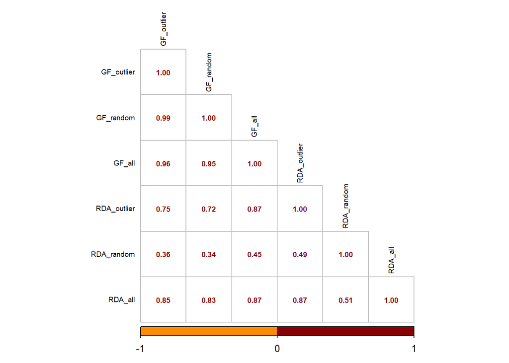

```r
correlation_present <- cor(df_present_combined)
correlation_present_order <- correlation_present[c(2,3,1,5,6,4),c(2,3,1,5,6,4)]
colnames(correlation_present_order) <- c("GF_outlier","GF_random","GF_all","RDA_outlier","RDA_random","RDA_all")
row.names(correlation_present_order) <- c("GF_outlier","GF_random","GF_all","RDA_outlier","RDA_random","RDA_all")

corrplot(correlation_present_order, method = "number", addrect = 2, col = c("darkorange","darkred"), type = "lower", tl.col = "black", tl.cex = 0.6, number.cex = 0.6)
```

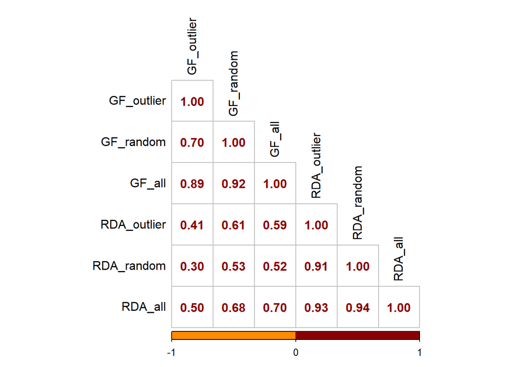

```r
correlation_future <- cor(df_future_combined)
correlation_future_order <- correlation_future[c(3,5,1,8,10,6),c(3,5,1,8,10,6)]
colnames(correlation_future_order) <- c("GF_outlier","GF_random","GF_all","RDA_outlier","RDA_random","RDA_all")
row.names(correlation_future_order) <- c("GF_outlier","GF_random","GF_all","RDA_outlier","RDA_random","RDA_all")

corrplot(correlation_future_order, method = "number", addrect = 2, col = c("darkorange","darkred"), type = "lower", tl.col = "black", tl.cex = 1, number.cex = 1)
```

```r
pdf("C:/Users/tfrancisco/Documents/Thesis/Results/species/taxus/Genomic_offset/comparison/correlation_GO_present_values_GF_RDA_reduce_paper.pdf");corrplot(correlation_present_order, method = "number", addrect = 2, col = c("darkorange","darkred"), type = "lower", tl.col = "black", tl.cex = 0.6, number.cex = 0.6);dev.off()
```

```r
pdf("C:/Users/tfrancisco/Documents/Thesis/Results/species/taxus/Genomic_offset/comparison/correlation_GO_future_values_GF_RDA_reduce_paper.pdf");corrplot(correlation_future_order, method = "number", addrect = 2, col = c("darkorange","darkred"), type = "lower", tl.col = "black", tl.cex = 1, number.cex = 1);dev.off()
```

## All the sets

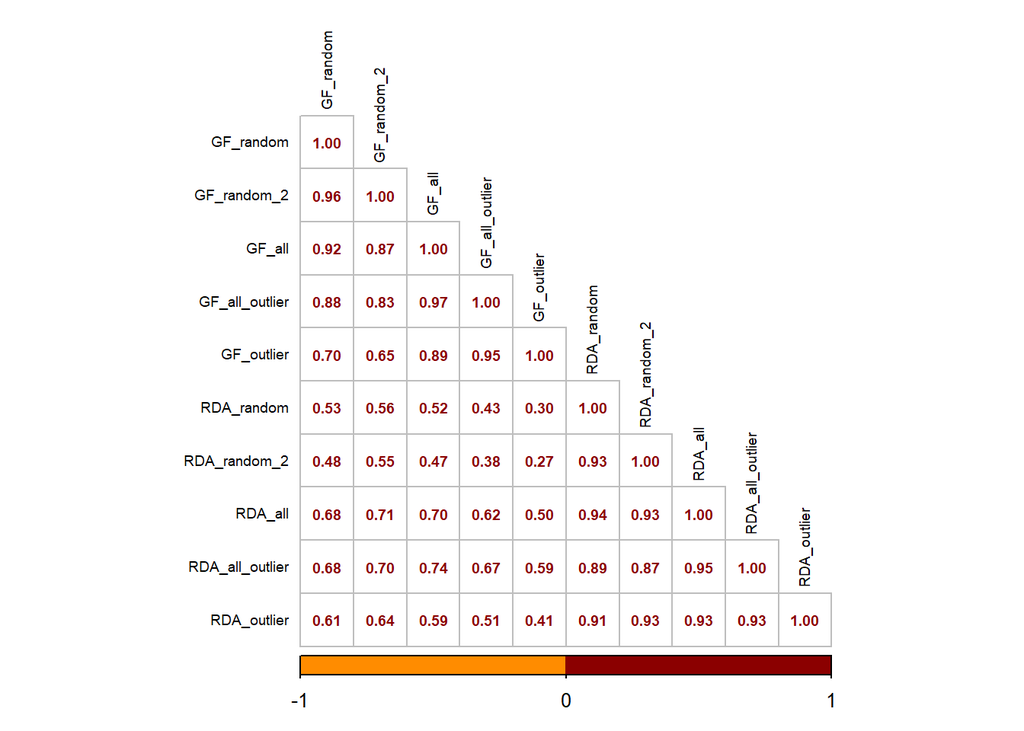

```r
correlation_future <- cor(df_future_combined)
correlation_future_order_allset <- correlation_future[c(1,2,3,4,5,6,7,8,9,10),c(1,2,3,4,5,6,7,8,9,10)]
correlation_future_order_allset <- correlation_future[c(5,4,1,2,3,10,9,6,7,8),c(5,4,1,2,3,10,9,6,7,8)]

colnames(correlation_future_order_allset) <- c("GF_random","GF_random_2","GF_all","GF_all_outlier","GF_outlier","RDA_random","RDA_random_2","RDA_all","RDA_all_outlier","RDA_outlier")
row.names(correlation_future_order_allset) <- c("GF_random","GF_random_2","GF_all","GF_all_outlier","GF_outlier","RDA_random","RDA_random_2","RDA_all","RDA_all_outlier","RDA_outlier")

corrplot(correlation_future_order_allset, method = "number", addrect = 2, col = c("darkorange","darkred"), type = "lower", tl.col = "black", tl.cex = 0.6, number.cex = 0.6)
```

```r
pdf("C:/Users/tfrancisco/Documents/Thesis/Results/species/taxus/Genomic_offset/comparison/correlation_new_modelsV2.pdf");corrplot(correlation_future_order_allset, method = "number", addrect = 2, col = c("darkorange","darkred"), type = "lower", tl.col = "black", tl.cex = 0.6, number.cex = 0.6);dev.off()
```

```r
pdf("C:/Users/tfrancisco/Documents/Thesis/Results/species/taxus/Genomic_offset/comparison/correlation_GO_future_values_GF_RDA_allsets.pdf");corrplot(correlation_future_order_allset, method = "number", addrect = 2, col = c("darkorange","darkred"), type = "lower", tl.col = "black", tl.cex = 1, number.cex = 1);dev.off()
```

# Comparison GO rank

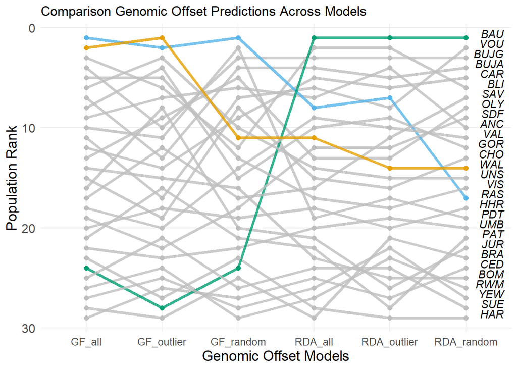

```r
GO_T_Adapcon_Gentree_GF_outlier_future_mean <- GO_T_Adapcon_Gentree_GF_LC_future_mean
GO_T_Adapcon_Gentree_RDA_outlier_future_mean <- GO_T_Adapcon_Gentree_RDA_LC_future_mean

GO_T_Adapcon_Gentree_GF_random_future_mean <- GO_T_Adapcon_Gentree_GF_random_same_AF_future_mean
GO_T_Adapcon_Gentree_RDA_random_future_mean <- GO_T_Adapcon_Gentree_RDA_random_same_AF_future_mean

# List of SNP sets
#list_set <- c("all", "random", "random_same_AF", "LC", "MC", "CG")

list_set <- c("GF_outlier","GF_random","GF_all","RDA_outlier","RDA_random","RDA_all")

# Initialize an empty list to store data for all SNP sets
plot_data <- list()

# Load the RColorBrewer package for dynamic color palettes
library(RColorBrewer)

color_palette <- c("#E69F00",  # Orange
                   "#56B4E9",  # Sky Blue
                   "#009E73",  # Green
                   "#F0E442",  # Yellow
                   "#0072B2",  # Blue
                   "#D55E00",  # Red
                   "#CC79A7")  # Pink


ranks_df <- data.frame()
all_top_populations <- character(0)

meta_data_pop$pop_abbrev <- c("VIS","BAU","SDF","PAT","CHO","VOU","OLY","ANC","PDT","UMB","VAL","BRA","HAR","GOR","BOM","UNS","BUJA","BUJG","CAR","RAS","SUE","SAV","BLI","HHR","JUR","WAL","CED","RWM","YEW")

meta_data_f <- meta_data_pop[order(meta_data_pop$Population),]

# Loop over each climatic model
for (i in 1:length(list_set)) {

  set <- list_set[i]
  # Get the genomic offset data for the current SNP set and model
  GO_data <- get(paste0("GO_T_Adapcon_Gentree_", set, "_future_mean"))
  colnames(GO_data) <- c("Population", "GO")

  # Rank the populations by genomic offset (highest GO gets rank 1)
  GO_data$Rank <- rank(-GO_data$GO, ties.method = "first")

  # Add columns for the climatic model and SNP set
  GO_data$Set <- set

  # Append to ranks dataframe
  ranks_df <- rbind(ranks_df, GO_data)

  # Find the top (rank 1) and bottom (rank 29) populations
  top_population <- GO_data %>% filter(Rank == 1) %>% pull(Population)
  #bottom_population <- GO_data %>% filter(Rank == max(GO_data$Rank)) %>% pull(Population)

  # Store unique top and bottom populations
  all_top_populations <- unique(c(all_top_populations, top_population))#bottom_population
}

# Adjust the number of colors if needed
num_top_populations <- length(all_top_populations)
if (num_top_populations > length(color_palette)) {
  color_palette <- colorRampPalette(brewer.pal(9, "Set1"))(num_top_populations)
}

# Assign a unique color to each of the selected populations (both top and bottom)
population_colors <- setNames(color_palette[1:num_top_populations], all_top_populations)

# Create a new column to store color assignments (highlight only rank 1 and rank 29 populations)
ranks_df$Highlight <- ifelse(ranks_df$Population %in% all_top_populations, ranks_df$Population, "Other")

# Map colors for top & bottom populations and grey for the rest
ranks_df$Color <- ifelse(ranks_df$Highlight == "Other", "grey", population_colors[ranks_df$Highlight])

# Store the data frame for this SNP set in the plot_data list
plot_data[[set]] <- ranks_df

# Generate the plot for this SNP set
p <- ggplot(ranks_df, aes(x = Set, y = Rank, group = Population, color = Color)) +
  geom_line(alpha = 0.8, size = 1.25) +
  geom_point(size = 2) +
  geom_text(
    data = ranks_df %>% filter(Set == list_set[5]),  # Label only in first column
    aes(label = meta_data_f$pop_abbrev[match(Population, meta_data_f$Population)]),
    hjust = 1,  # Align to the left
    vjust = 0,
    size = 3.8,   # Increase text size
    nudge_x = +0.50,
    fontface= "italic",color="black"
    # Move text further left
  ) +
  scale_y_reverse() +  # Reverse rank (1 = top)
  scale_color_identity() +  # Use assigned colors
  labs(
    title = "Comparison Genomic Offset Predictions Across Models",
    x = "Genomic Offset Models", y = "Population Rank"
  ) +
  theme_minimal() +
  theme(
    legend.position = "none",
    panel.grid.minor = element_blank(),
    strip.text = element_text(size = 10, face = "bold"),
    legend.title = element_text(size = 10),
              axis.title.x = element_text(size = 14),
              axis.title.y = element_text(size = 14),
              axis.text.x = element_text(size = 10),
              axis.text.y = element_text(size = 12),
              legend.text = element_text(size = 12)
  )

print(p)  # Display plot
```

```r
#save
    pdf(paste0("C:/Users/tfrancisco/Documents/Thesis/Results/species/taxus/Genomic_offset/comparison/GO_rank_comparison_across_models.pdf"));print(p);dev.off()
```

## Including bottom populations

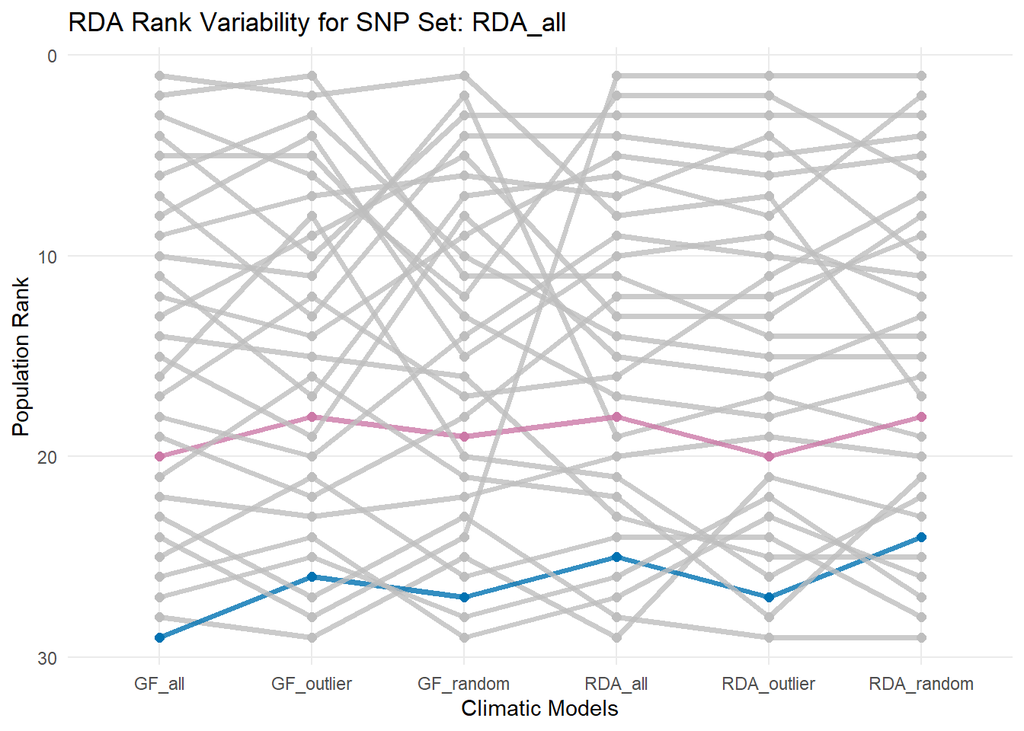

```r
color_palette <- c("#E69F00",  # Orange
                   "#56B4E9",  # Sky Blue
                   "#009E73",  # Green
                   "#F0E442",  # Yellow
                   "#0072B2",  # Blue
                   "#D55E00",  # Red
                   "#CC79A7")  # Pink

color_palette <- c("#0072B2","#CC79A7")  # Orange


ranks_df <- data.frame()
all_top_populations <- character(0)

# Loop over each climatic model
for (i in 1:length(list_set)) {

  set <- list_set[i]
  # Get the genomic offset data for the current SNP set and model
  GO_data <- get(paste0("GO_T_Adapcon_Gentree_", set, "_future_mean"))
  colnames(GO_data) <- c("Population", "GO")

  # Rank the populations by genomic offset (highest GO gets rank 1)
  GO_data$Rank <- rank(-GO_data$GO, ties.method = "first")

  # Add columns for the climatic model and SNP set
  GO_data$Set <- set

  # Append to ranks dataframe
  ranks_df <- rbind(ranks_df, GO_data)

  # Find the top (rank 1) and bottom (rank 29) populations
  top_population <- GO_data %>% filter(Rank == 1) %>% pull(Population)
  bottom_population <- GO_data %>% filter(Rank == max(GO_data$Rank)) %>% pull(Population)

  # Store unique top and bottom populations
  all_top_populations <- unique(c(all_top_populations, top_population, bottom_population))
}

# Adjust the number of colors if needed
num_top_populations <- length(bottom_population)
if (num_top_populations > length(color_palette)) {
  color_palette <- colorRampPalette(brewer.pal(9, "Set1"))(num_top_populations)
}
#Castle_Eden_Dene
# Assign a unique color to each of the selected populations (both top and bottom)
keep_pop <- c("Castle_Eden_Dene","Hornli-Hulftegg-Roten")

population_colors <- setNames(color_palette[1:2], keep_pop)

# Create a new column to store color assignments (highlight only rank 1 and rank 29 populations)
ranks_df$Highlight <- ifelse(ranks_df$Population %in% keep_pop, ranks_df$Population, "Other")

# Map colors for top & bottom populations and grey for the rest
ranks_df$Color <- ifelse(ranks_df$Highlight == "Other", "grey", population_colors[ranks_df$Highlight])

# Store the data frame for this SNP set in the plot_data list
plot_data[[set]] <- ranks_df

# Generate the plot for this SNP set
p <- ggplot(ranks_df, aes(x = Set, y = Rank, group = Population, color = Color)) +
  geom_line(alpha = 0.8, size = 1.25) +
  geom_point(size = 2) +
  scale_y_reverse() +  # Reverse rank (1 = top)
  scale_color_identity() +  # Use assigned colors
  labs(
    title = paste("RDA Rank Variability for SNP Set:", set),
    x = "Climatic Models", y = "Population Rank"
  ) +
  theme_minimal() +
  theme(
    legend.position = "none",  # Remove legend
    panel.grid.minor = element_blank(),
    strip.text = element_text(size = 10, face = "bold"),
    legend.title = element_text(size = 10)
  )

print(p)  # Display plot
```

```r
#save
     pdf(paste0("C:/Users/tfrancisco/Documents/Thesis/Results/species/taxus/Genomic_offset/comparison/GO_rank_similarity.pdf"));print(p);dev.off()
```

# GO map

## Map biplot without low trust

Based on the evaluation of the predictions using phenotypic data, we concluded that GF and RDA predictions using a set of loci with random same-allele frequencies should be used to predict genomic offset. Only predictions for populations where the two methods agree would be interpreted.

```r
df_two_GO <- data.frame(Population=GO_T_Adapcon_Gentree_GF_all_future_mean[,1],df_future_combined[,c(3,6)])

df_two_GO_outliers <- data.frame(Population=GO_T_Adapcon_Gentree_GF_all_future_mean[,1],df_future_combined[,c(3,8)])
df_two_GO_random_same_AF <- data.frame(Population=GO_T_Adapcon_Gentree_GF_all_future_mean[,1],df_future_combined[,c(5,10)])
df_two_GO_random_same_AFV2 <- data.frame(Population=GO_T_Adapcon_Gentree_GF_all_future_mean[,1],df_future_combined[,c(4,9)])
df_two_GO_all_outliers <- data.frame(Population=GO_T_Adapcon_Gentree_GF_all_future_mean[,1],df_future_combined[,c(2,7)])
```

We can plot the two GO for each population using two different colors:

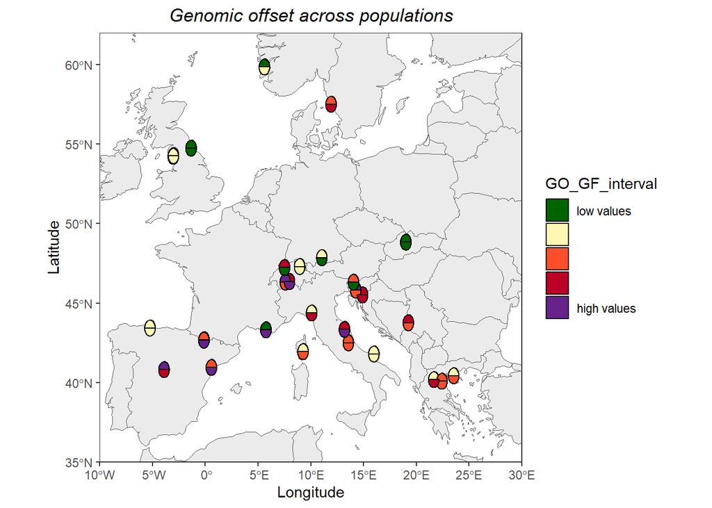

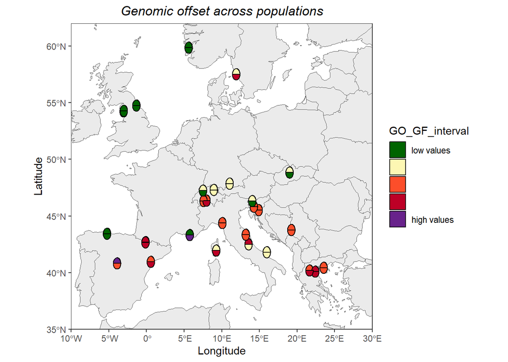

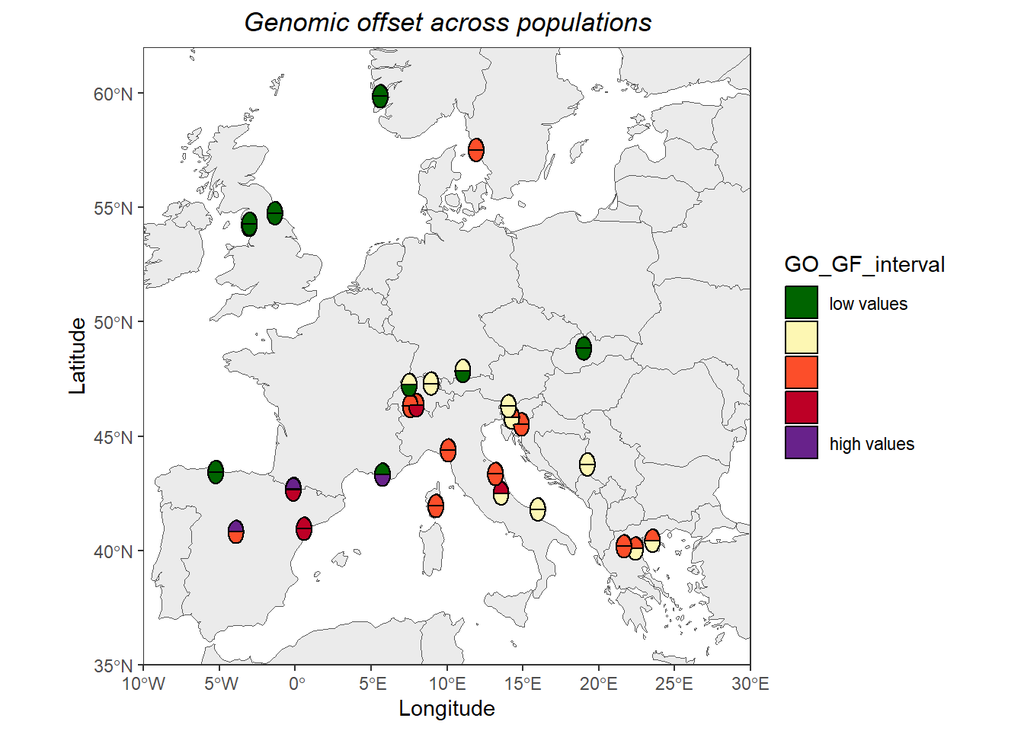

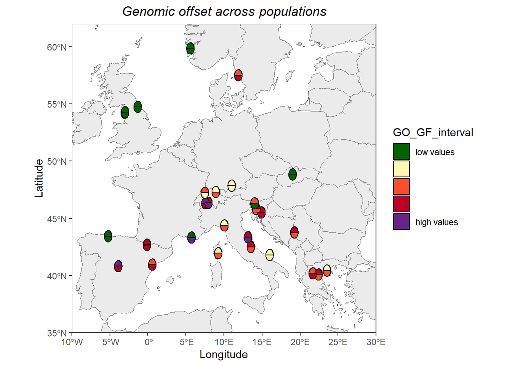

```r
list_df_combined <- c("df_two_GO_outliers","df_two_GO_random_same_AF","df_two_GO_random_same_AFV2","df_two_GO_all_outliers")
list_names <- c("outlier","random_AF","random_AF2","all_outliers")

for(x in 1:length(list_df_combined)){

  df <- get(list_df_combined[x])
  name <- list_names[x]
Genomic_offset_combined <- merge(df,meta_data_pop_order[,c(2,4,5)],"Population")
# DataFrame containing GO values for two models (RDA and GF)
   colnames(Genomic_offset_combined) <- c("Population", "GO_GF", "GO_RDA","Latitude", "Longitude")

    # Convert Longitude and Latitude to numeric
    Genomic_offset_combined <- Genomic_offset_combined %>%
      mutate(Longitude = as.numeric(Longitude), Latitude = as.numeric(Latitude))

 colors <- c("darkgreen", "#FDF7B3", "#FC4E2A", "#BD0026", "darkorchid4")
admin <- ne_countries(scale = "medium", returnclass = "sf")

#scale the values to have comparable classes
#cut_interval

Genomic_offset_combined$scaled_GO_RDA <- (Genomic_offset_combined$GO_RDA-min(Genomic_offset_combined$GO_RDA))/(max(Genomic_offset_combined$GO_RDA)-min(Genomic_offset_combined$GO_RDA))

# Create interval categories for `GO_GF` and `GO_RDA`
Genomic_offset_combined <- Genomic_offset_combined %>%
  mutate(GO_GF_interval = cut_interval(GO_GF, n = 5, labels = FALSE),
         GO_RDA_interval = cut_interval(GO_RDA, n = 5, labels = FALSE))

# Convert intervals to factor for consistent color mapping
Genomic_offset_combined$GO_GF_interval <- as.factor(Genomic_offset_combined$GO_GF_interval)
Genomic_offset_combined$GO_RDA_interval <- as.factor(Genomic_offset_combined$GO_RDA_interval)

# Plot with vertical split for the half-circles
plot <- ggplot(data = Genomic_offset_combined) +
  geom_sf(data = admin, fill = gray(0.92), size = 0) +
  geom_sf(data = admin, fill = NA, size = 0.1) +
  coord_sf(xlim = c(-10, 30), ylim = c(35, 62), expand = FALSE) +
  # Create half-circle markers with a vertical split by rotating the start and end angles
  geom_arc_bar(aes(
    x0 = Longitude, y0 = Latitude, r0 = 0, r = 0.5,
    start = -pi/2, end = pi/2, fill = GO_GF_interval  # Left half for GO_GF
  ), color = "black", data = Genomic_offset_combined) +
  geom_arc_bar(aes(
    x0 = Longitude, y0 = Latitude, r0 = 0, r = 0.5,
    start = pi/2, end = 3 * pi/2, fill = GO_RDA_interval  # Right half for GO_RDA
  ), color = "black", data = Genomic_offset_combined) +

  # Set fill colors and map details for intervals
  scale_fill_manual(
    values = colors,
    labels = c("low values", "", "", "", "high values"),
    drop = FALSE, na.translate = FALSE
  ) +
  xlab("Longitude") + ylab("Latitude") +
  ggtitle("Genomic offset across populations") +
  theme_bw(base_size = 11) +
  theme(
    legend.position = "right", panel.grid = element_blank(),
    strip.text = element_text(size = 11),
    plot.title = element_text(hjust = 0.5, color = "Black", face = "italic")
  )

# Print the plot
print(plot)

assign(paste0("Genomic_offset_combined_",name),Genomic_offset_combined)

}
```

```r
#pdf("C:/Users/tfrancisco/Documents/Thesis/Results/species/taxus/Genomic_offset/Final_figures/GO_RDA_across_populations.pdf");print(plot);dev.off()
```

## Indicating low trust population

Plot of GO highlighting the populations we are less trusting of.

### At least two categorical of difference for random same AF

```r
for(x in 1:length(list_names)){

  df <- get(paste0("Genomic_offset_combined_",list_names[x]))

  Genomic_offset_combined_MC <- df[-c(9,19,21,22,23),]
Genomic_offset_combined_MC_elev <- merge(Genomic_offset_combined_MC,meta_data_pop_order[,c(2,6)],"Population")
Genomic_offset_combined_MC_elev$Elevation.DEM_90m.<- as.numeric(Genomic_offset_combined_MC_elev$Elevation.DEM_90m.)
Genomic_offset_combined_MC_elev$Latitude<- as.numeric(Genomic_offset_combined_MC_elev$Latitude)

cor(Genomic_offset_combined_MC_elev$GO_GF,Genomic_offset_combined_MC_elev$Latitude)
}

Genomic_offset_combined_random_AF
```

```
##                     Population       GO_GF     GO_RDA Latitude  Longitude
## 1                       Ancona 0.020504063 0.06891124 43.35068 13.1988917
## 2                     Blindtal 0.017416033 0.07302145 46.35519  7.9903570
## 3       Bohinj_Obrne_Mokri_Log 0.014918901 0.04431264 46.31436 14.0550770
## 4               Brandvik_Stord 0.006118212 0.04477659 59.85280  5.6104660
## 5            Bujaruelo-ADAPCON 0.021863894 0.07461664 42.70098 -0.1165162
## 6          Bujaruelo-GENTREE-1 0.022266494 0.07496925 42.67478 -0.1232048
## 7                        Cardo 0.017906489 0.07347198 40.95839  0.5876957
## 8             Castle_Eden_Dene 0.004919315 0.04443507 54.74464 -1.3344239
## 9  Fonte_tassete_Prati_di_Tivo 0.024241671 0.05447067 42.50618 13.5659382
## 10               Foresta_Umbra 0.011806892 0.05247863 41.80630 15.9830000
## 11                Gorenja_zaga 0.016022083 0.06661883 45.51882 14.9112200
## 12                    Harmanec 0.010292957 0.03305003 48.83560 19.0132000
## 13       Hornli-Hulftegg-Roten 0.013521115 0.05695896 47.30408  8.9493621
## 14                        Jura 0.012802252 0.04497744 47.24159  7.5183380
```

[output cut: 45 more lines]

```r
removed_pop <- c("Fonte_tassete_Prati_di_Tivo","Rascafria","Sainte_Baume","Saro_Vasterskog","Serra_di_Fiumorbu")

Genomic_offset_combined_randomAF_elev <- merge(Genomic_offset_combined_random_AF,meta_data_pop_order[,c(2,6)],"Population")
Genomic_offset_combined_randomAF_elev$Elevation.DEM_90m.<- as.numeric(Genomic_offset_combined_randomAF_elev$Elevation.DEM_90m.)
Genomic_offset_combined_randomAF_elev$Latitude<- as.numeric(Genomic_offset_combined_randomAF_elev$Latitude)

Genomic_offset_combined_randomAF_elev_reduce <- Genomic_offset_combined_randomAF_elev[-c(9,19,21,22,23),]
cor(Genomic_offset_combined_randomAF_elev_reduce$GO_GF,Genomic_offset_combined_randomAF_elev_reduce$Elevation.DEM_90m.)
```

```
## [1] 0.7217921
```

```r
cor(Genomic_offset_combined_randomAF_elev_reduce$GO_RDA,Genomic_offset_combined_randomAF_elev_reduce$Elevation.DEM_90m.)
```

```
## [1] 0.6029465
```

```r
Genomic_offset_combined_randomAF_elev_reduce <- Genomic_offset_combined_randomAF_elev_reduce %>%
  mutate(mean_values = (GO_GF + GO_RDA) / 2)

cor(Genomic_offset_combined_randomAF_elev_reduce$mean_values,Genomic_offset_combined_randomAF_elev_reduce$Elevation.DEM_90m.)
```

```
## [1] 0.6499934
```

```r
cor(Genomic_offset_combined_randomAF_elev_reduce$mean_values,Genomic_offset_combined_randomAF_elev_reduce$Latitude)
```

```
## [1] -0.7102025
```

```r
s <- cor.test(Genomic_offset_combined_randomAF_elev_reduce$mean_values,Genomic_offset_combined_randomAF_elev_reduce$Elevation.DEM_90m.)
s$p.value
```

```
## [1] 0.0005860178
```

```r
s <- cor.test(Genomic_offset_combined_randomAF_elev_reduce$mean_values,Genomic_offset_combined_randomAF_elev_reduce$Latitude)
s$p.value
```

```
## [1] 0.0001010691
```

```r
Genomic_offset_combined_randomAF_elev_reduce$pop_abbrev <- c("ANC","BLI","BOM","BRA","BUJA","BUJG","CAR","CED","UMB","GOR","HAR","HHR","JUR","CHO","OLY","VOU","PAT","RWM","SUE","UNS","VAL","VIS","WAL","YEW")

#plot
plot_elevation <- ggplot(data=Genomic_offset_combined_randomAF_elev_reduce, aes(x=Elevation.DEM_90m.,y=mean_values))+
  geom_point(aes(size=Latitude)) +
  geom_text(label=Genomic_offset_combined_randomAF_elev_reduce$pop_abbrev,vjust=1.8)
pdf("C:/Users/tfrancisco/Documents/Thesis/Results/species/taxus/Genomic_offset/Elevation_Latitude_gradients/plot_GO_elevation.pdf");print(plot_elevation);dev.off()
```

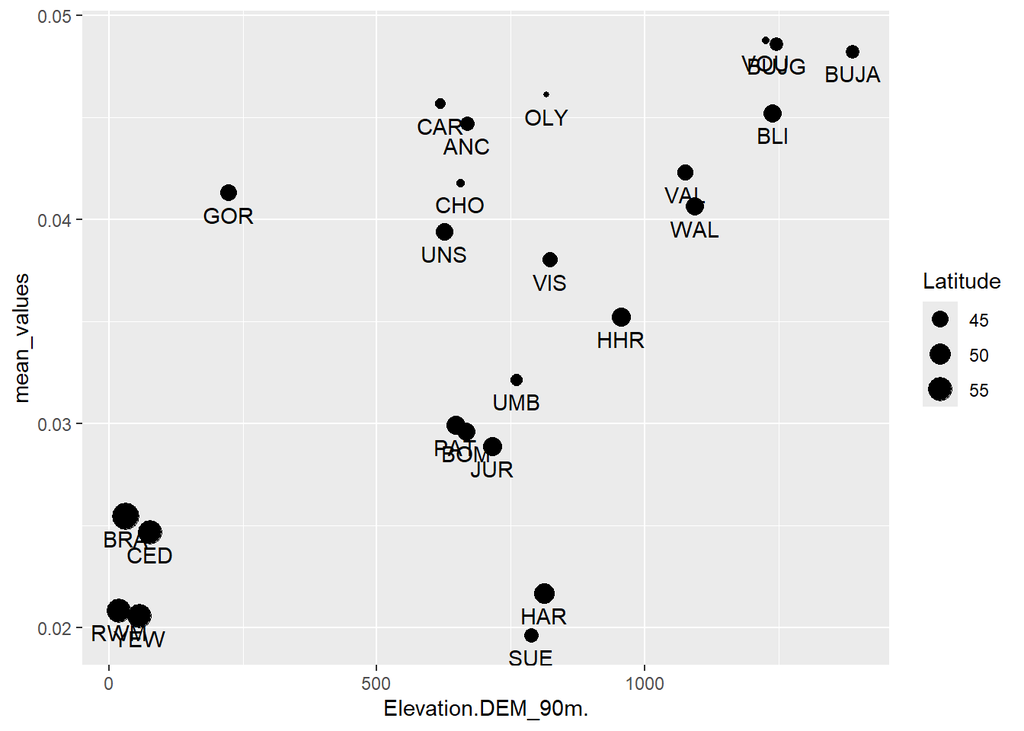

```r
  plot_elevation
```

```r
plot_latitude <- ggplot(data=Genomic_offset_combined_randomAF_elev_reduce, aes(x=Latitude,y=mean_values))+
  geom_point()+
   geom_text(label=Genomic_offset_combined_randomAF_elev_reduce$pop_abbrev,vjust=1.3)

pdf("C:/Users/tfrancisco/Documents/Thesis/Results/species/taxus/Genomic_offset/Elevation_Latitude_gradients/plot_GO_latitude.pdf");print(plot_latitude);dev.off()
```

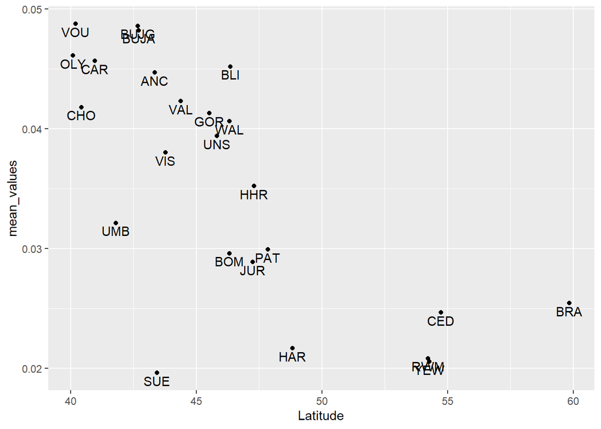

```r
  plot_latitude
```

```r
  #cor GO per method
cor(Genomic_offset_combined_randomAF_elev_reduce$GO_RDA,Genomic_offset_combined_randomAF_elev_reduce$Latitude)
```

```
## [1] -0.6617696
```

```r
cor(Genomic_offset_combined_randomAF_elev_reduce$GO_GF,Genomic_offset_combined_randomAF_elev_reduce$Latitude)
```

```
## [1] -0.7809332
```

```r
#all outliers
Genomic_offset_combined_alloutliers_elev <-merge(Genomic_offset_combined_all_outliers,meta_data_pop_order[,c(2,6)],"Population")
Genomic_offset_combined_alloutliers_elev$Elevation.DEM_90m.<- as.numeric(Genomic_offset_combined_alloutliers_elev$Elevation.DEM_90m.)

Genomic_offset_combined_allout_elev_reduce <- Genomic_offset_combined_alloutliers_elev[-c(3,21),]
cor(Genomic_offset_combined_allout_elev_reduce$GO_GF,Genomic_offset_combined_allout_elev_reduce$Elevation.DEM_90m.)
```

```
## [1] 0.6010643
```

```r
cor(Genomic_offset_combined_allout_elev_reduce$GO_RDA,Genomic_offset_combined_allout_elev_reduce$Elevation.DEM_90m.)
```

```
## [1] 0.5529983
```

```r
cor(Genomic_offset_combined_allout_elev_reduce$GO_GF,Genomic_offset_combined_allout_elev_reduce$Latitude)
```

```
## [1] -0.5503734
```

```r
cor(Genomic_offset_combined_allout_elev_reduce$GO_RDA,Genomic_offset_combined_allout_elev_reduce$Latitude)
```

```
## [1] -0.5013869
```

GOOD FIGURE

### Combined random AF

```r
removed_pop <- c("Fonte_tassete_Prati_di_Tivo","Rascafria","Sainte_Baume","Saro_Vasterskog","Serra_di_Fiumorbu")
shapefile <- st_read("C:/Users/tfrancisco/Documents/Thesis/Data/Species/Taxus_baccata/shapefiles/Taxus_baccata_plg_clip.shp")
```

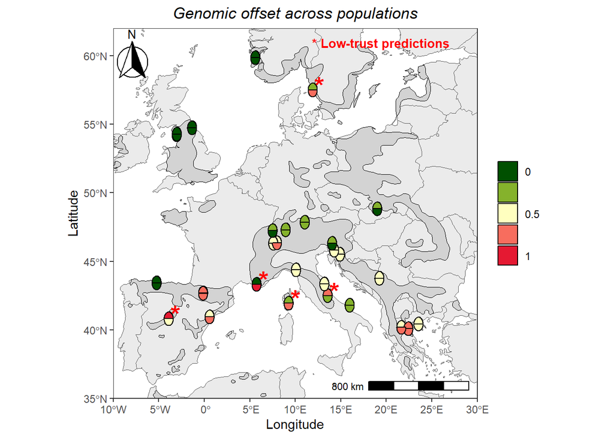

```r
library(colorBlindness)

colors <- c("darkgreen","lightgreen","#FDF7B3",
            "#FC4E2A","red")
colors <- c("#004CFF","#00E5FF","#FFFF80","#FFAA00","#FF0000")
colors <- c("darkgreen","lightgreen","#FFFF80","#FFAA00","#FF0000")

colors <- c("#290AD8","#AAF7FF","#FFFFBF","#F76D5E","#FF0000")
colors <- c("#005000","#85B22C","#FFFFBF","#F76D5E","#E51932")
#colors <- c("#005000","#85B22C","#ffff6d","#F76D5E","#E51932")

#standardised
 Genomic_offset_combined_random_AF$scaled_GO_RDA <- (Genomic_offset_combined_random_AF$GO_RDA-min(Genomic_offset_combined_random_AF$GO_RDA))/(max(Genomic_offset_combined_random_AF$GO_RDA)-min(Genomic_offset_combined_random_AF$GO_RDA))

  Genomic_offset_combined_random_AF$scaled_GO_GF <- (Genomic_offset_combined_random_AF$GO_GF-min(Genomic_offset_combined_random_AF$GO_GF))/(max(Genomic_offset_combined_random_AF$GO_GF)-min(Genomic_offset_combined_random_AF$GO_GF))

plot <- ggplot(data = Genomic_offset_combined_random_AF) +
  geom_sf(data = admin, fill = gray(0.92), size = 0) +
  geom_sf(data = admin, fill = NA, size = 0.1) +
  geom_sf(data = shapefile, fill = "lightgrey", color = "black", size = 0.2) +  # Adding shapefile
  coord_sf(xlim = c(-10, 30), ylim = c(35, 62), expand = FALSE) +
  # Plot half-circles as usual for the genomic offsets
  geom_arc_bar(aes(
    x0 = Longitude, y0 = Latitude, r0 = 0, r = 0.5,
    start = -pi/2, end = pi/2, fill = GO_GF_interval
  ), color = "black", data = Genomic_offset_combined_random_AF) +

  geom_arc_bar(aes(
    x0 = Longitude, y0 = Latitude, r0 = 0, r = 0.5,
    start = pi/2, end = 3 * pi/2, fill = GO_RDA_interval
  ), color = "black", data = Genomic_offset_combined_random_AF) +

  # Add asterisk (*) slightly to the left of the circle for low-trust populations
  geom_text(
    data = Genomic_offset_combined_random_AF %>% filter(Population %in% removed_pop),
    aes(x = Longitude + 0.75, y = Latitude+0.3, label = "*"),  # Adjust the offset value as needed
    color = "red", size = 7.5, fontface = "bold"
  ) +

  # Color scale and other plot details
  scale_fill_manual(
    name = NULL,  # Removes the legend title
    values = colors,
    labels = c("0", "", "0.5", "", "1"),
    drop = FALSE, na.translate = FALSE
  ) +
  annotate("text", x = Inf, y = Inf, label = "* Low-trust predictions",
           hjust = 1.2, vjust = 2, color = "red", size = 3.5, fontface = "bold") +
  xlab("Longitude") + ylab("Latitude") +
  ggtitle("Genomic offset across populations") +
  annotation_scale(location = "br", width_hint = 0.3) + # Scale bar at bottom left
  annotation_north_arrow(location = "tl", which_north = "true",
                         pad_x = unit(-0.2, "cm"), pad_y = unit(0.08, "cm"),
                         style = north_arrow_fancy_orienteering) + # Compass rose
  theme_bw(base_size = 11) +
  theme(
    legend.position = "right", panel.grid = element_blank(),
    strip.text = element_text(size = 11),
    plot.title = element_text(hjust = 0.5, color = "Black", face = "italic")
  )

print(plot)
```

```r
pdf("C:/Users/tfrancisco/Documents/Thesis/Results/species/taxus/Genomic_offset/Final_figures/GO_map_final_highli_bad_predict_new_colorsV2.pdf");print(plot);dev.off()
```

```r
removed_pop <- c("Fonte_tassete_Prati_di_Tivo","Rascafria","Sainte_Baume","Saro_Vasterskog","Serra_di_Fiumorbu")
shapefile <- st_read("C:/Users/tfrancisco/Documents/Thesis/Data/Species/Taxus_baccata/shapefiles/Taxus_baccata_plg_clip.shp")
```

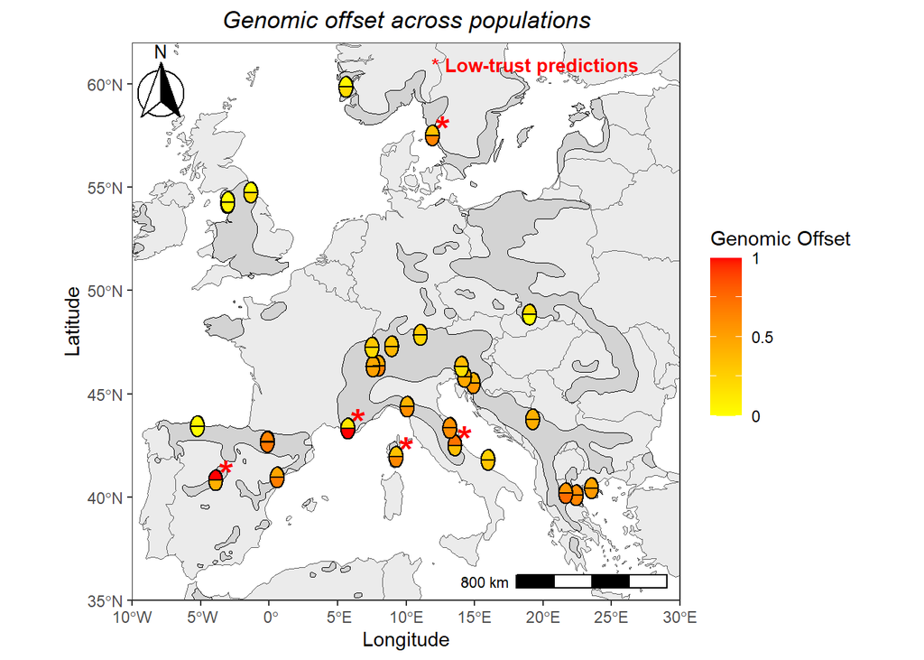

```r
 colors <- c("darkgreen", "#FDF7B3", "#FC4E2A", "#BD0026", "darkorchid4")
 colors <- c("#005000","#85B22C","#FFFFBF","#F76D5E","#E51932")


plot <- ggplot(data = Genomic_offset_combined_random_AF) +
  geom_sf(data = admin, fill = gray(0.92), size = 0) +
  geom_sf(data = admin, fill = NA, size = 0.1) +
  geom_sf(data = shapefile, fill = "lightgrey", color = "black", size = 0.2) +  # Adding shapefile
  coord_sf(xlim = c(-10, 30), ylim = c(35, 62), expand = FALSE) +
  # Plot half-circles as usual for the genomic offsets
  geom_arc_bar(aes(
    x0 = Longitude, y0 = Latitude, r0 = 0, r = 0.5,
    start = -pi/2, end = pi/2, fill = scaled_GO_GF  # Ensure it's numeric
  ), color = "black", data = Genomic_offset_combined_random_AF) +

  geom_arc_bar(aes(
    x0 = Longitude, y0 = Latitude, r0 = 0, r = 0.5,
    start = pi/2, end = 3 * pi/2, fill = scaled_GO_RDA  # Ensure it's numeric
  ), color = "black", data = Genomic_offset_combined_random_AF) +

  # Add asterisk (*) slightly to the left of the circle for low-trust populations
  geom_text(
    data = Genomic_offset_combined_random_AF %>% filter(Population %in% removed_pop),
    aes(x = Longitude + 0.75, y = Latitude + 0.3, label = "*"),  # Adjust the offset value as needed
    color = "red", size = 7.5, fontface = "bold"
  ) +

  # Color gradient scale with more pronounced red for higher values
  scale_fill_gradient(
    name = NULL,  # Removes the legend title
    low = "yellow", high = "red",
    limits = c(0, 1),  # Explicitly set the range to enhance contrast
    labels = c("0", "", "0.5", "", "1"),
    na.value = "gray", guide = guide_colorbar(title = "Genomic Offset")
  ) +
  annotate("text", x = Inf, y = Inf, label = "* Low-trust predictions",
           hjust = 1.2, vjust = 2, color = "red", size = 3.5, fontface = "bold") +
  xlab("Longitude") + ylab("Latitude") +
  ggtitle("Genomic offset across populations") +
  annotation_scale(location = "br", width_hint = 0.3) + # Scale bar at bottom left
  annotation_north_arrow(location = "tl", which_north = "true",
                         pad_x = unit(-0.2, "cm"), pad_y = unit(0.08, "cm"),
                         style = north_arrow_fancy_orienteering) + # Compass rose
  theme_bw(base_size = 11) +
  theme(
    legend.position = "right", panel.grid = element_blank(),
    strip.text = element_text(size = 11),
    plot.title = element_text(hjust = 0.5, color = "Black", face = "italic")
  )

print(plot)
```

```r
#pdf("C:/Users/tfrancisco/Documents/Thesis/Results/species/taxus/Genomic_offset/Final_figures/GO_map_final_highli_bad_predict.pdf");print(plot);dev.off()
```

## Combined random AF V2

```r
removed_pop <- c("Fonte_tassete_Prati_di_Tivo","Rascafria","Sainte_Baume")
shapefile <- st_read("C:/Users/tfrancisco/Documents/Thesis/Data/Species/Taxus_baccata/shapefiles/Taxus_baccata_plg_clip.shp")
```

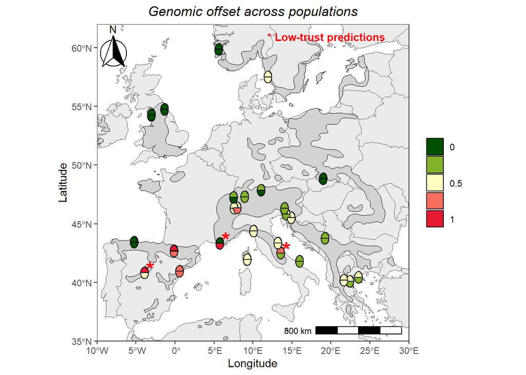

```r
colors <- c("#005000","#85B22C","#FFFFBF","#F76D5E","#E51932")
colors <- c("#005000","#85B22C","#FFFFBF","#F76D5E","#E51932")


Genomic_offset_combined_random_AF2$scaled_GO_RDA <- (Genomic_offset_combined_random_AF2$GO_RDA-min(Genomic_offset_combined_random_AF2$GO_RDA))/(max(Genomic_offset_combined_random_AF2$GO_RDA)-min(Genomic_offset_combined_random_AF2$GO_RDA))

  Genomic_offset_combined_random_AF2$scaled_GO_GF <- (Genomic_offset_combined_random_AF2$GO_GF-min(Genomic_offset_combined_random_AF2$GO_GF))/(max(Genomic_offset_combined_random_AF2$GO_GF)-min(Genomic_offset_combined_random_AF2$GO_GF))

plot <- ggplot(data = Genomic_offset_combined_random_AF2) +
  geom_sf(data = admin, fill = gray(0.92), size = 0) +
  geom_sf(data = admin, fill = NA, size = 0.1) +
  geom_sf(data = shapefile, fill = "lightgrey", color = "black", size = 0.2) +  # Adding shapefile
  coord_sf(xlim = c(-10, 30), ylim = c(35, 62), expand = FALSE) +
  # Plot half-circles as usual for the genomic offsets
  geom_arc_bar(aes(
    x0 = Longitude, y0 = Latitude, r0 = 0, r = 0.5,
    start = -pi/2, end = pi/2, fill = GO_GF_interval
  ), color = "black", data = Genomic_offset_combined_random_AF2) +

  geom_arc_bar(aes(
    x0 = Longitude, y0 = Latitude, r0 = 0, r = 0.5,
    start = pi/2, end = 3 * pi/2, fill = GO_RDA_interval
  ), color = "black", data = Genomic_offset_combined_random_AF2) +

  # Add asterisk (*) slightly to the left of the circle for low-trust populations
  geom_text(
    data = Genomic_offset_combined_random_AF2 %>% filter(Population %in% removed_pop),
    aes(x = Longitude + 0.75, y = Latitude+0.3, label = "*"),  # Adjust the offset value as needed
    color = "red", size = 7.5, fontface = "bold"
  ) +

  # Color scale and other plot details
  scale_fill_manual(
    name = NULL,  # Removes the legend title
    values = colors,
    labels = c("0", "", "0.5", "", "1"),
    drop = FALSE, na.translate = FALSE
  ) +
  annotate("text", x = Inf, y = Inf, label = "* Low-trust predictions",
           hjust = 1.2, vjust = 2, color = "red", size = 3.5, fontface = "bold") +
  xlab("Longitude") + ylab("Latitude") +
  ggtitle("Genomic offset across populations") +
  annotation_scale(location = "br", width_hint = 0.3) + # Scale bar at bottom left
  annotation_north_arrow(location = "tl", which_north = "true",
                         pad_x = unit(-0.2, "cm"), pad_y = unit(0.08, "cm"),
                         style = north_arrow_fancy_orienteering) + # Compass rose
  theme_bw(base_size = 11) +
  theme(
    legend.position = "right", panel.grid = element_blank(),
    strip.text = element_text(size = 11),
    plot.title = element_text(hjust = 0.5, color = "Black", face = "italic")
  )

print(plot)
```

```r
pdf("C:/Users/tfrancisco/Documents/Thesis/Results/species/taxus/Genomic_offset/Final_figures/GO_map_final_highli_bad_predict_randomV2_new_colors.pdf");print(plot);dev.off()
```

## Combined outliers

```r
removed_pop <- c("Bohinj_Obrne_Mokri_Log","Bujaruelo-ADAPCON","Bujaruelo-GENTREE-1","Cardo","Jura","Mt_Vourinos","Sainte_Baume","Unska_kolisevka","Valditacca","Wallis")
shapefile <- st_read("C:/Users/tfrancisco/Documents/Thesis/Data/Species/Taxus_baccata/shapefiles/Taxus_baccata_plg_clip.shp")
```

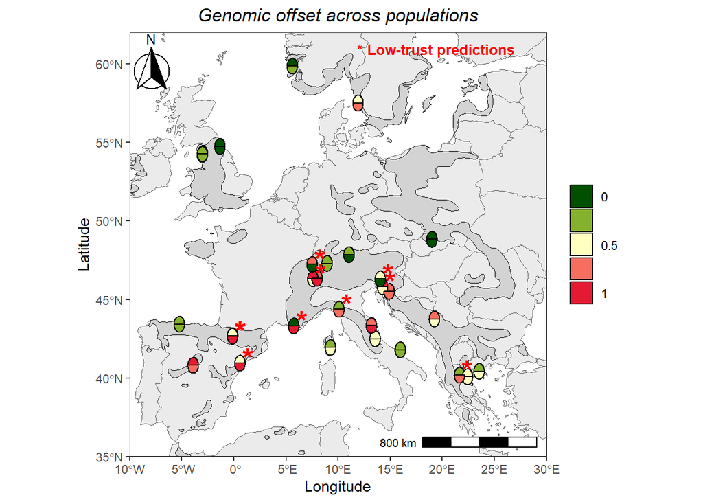

```r
colors <- c("#005000","#85B22C","#FFFFBF","#F76D5E","#E51932")

Genomic_offset_combined_outlier$scaled_GO_RDA <- (Genomic_offset_combined_outlier$GO_RDA-min(Genomic_offset_combined_outlier$GO_RDA))/(max(Genomic_offset_combined_outlier$GO_RDA)-min(Genomic_offset_combined_outlier$GO_RDA))

  Genomic_offset_combined_outlier$scaled_GO_GF <- (Genomic_offset_combined_outlier$GO_GF-min(Genomic_offset_combined_outlier$GO_GF))/(max(Genomic_offset_combined_outlier$GO_GF)-min(Genomic_offset_combined_outlier$GO_GF))

plot <- ggplot(data = Genomic_offset_combined_outlier) +
  geom_sf(data = admin, fill = gray(0.92), size = 0) +
  geom_sf(data = admin, fill = NA, size = 0.1) +
  geom_sf(data = shapefile, fill = "lightgrey", color = "black", size = 0.2) +  # Adding shapefile
  coord_sf(xlim = c(-10, 30), ylim = c(35, 62), expand = FALSE) +
  # Plot half-circles as usual for the genomic offsets
  geom_arc_bar(aes(
    x0 = Longitude, y0 = Latitude, r0 = 0, r = 0.5,
    start = -pi/2, end = pi/2, fill = GO_GF_interval
  ), color = "black", data = Genomic_offset_combined_outlier) +

  geom_arc_bar(aes(
    x0 = Longitude, y0 = Latitude, r0 = 0, r = 0.5,
    start = pi/2, end = 3 * pi/2, fill = GO_RDA_interval
  ), color = "black", data = Genomic_offset_combined_outlier) +

  # Add asterisk (*) slightly to the left of the circle for low-trust populations
  geom_text(
    data = Genomic_offset_combined_outlier %>% filter(Population %in% removed_pop),
    aes(x = Longitude + 0.75, y = Latitude+0.3, label = "*"),  # Adjust the offset value as needed
    color = "red", size = 7.5, fontface = "bold"
  ) +

  # Color scale and other plot details
  scale_fill_manual(
    name = NULL,  # Removes the legend title
    values = colors,
    labels = c("0", "", "0.5", "", "1"),
    drop = FALSE, na.translate = FALSE
  ) +
  annotate("text", x = Inf, y = Inf, label = "* Low-trust predictions",
           hjust = 1.2, vjust = 2, color = "red", size = 3.5, fontface = "bold") +
  xlab("Longitude") + ylab("Latitude") +
  ggtitle("Genomic offset across populations") +
  annotation_scale(location = "br", width_hint = 0.3) + # Scale bar at bottom left
  annotation_north_arrow(location = "tl", which_north = "true",
                         pad_x = unit(-0.2, "cm"), pad_y = unit(0.08, "cm"),
                         style = north_arrow_fancy_orienteering) + # Compass rose
  theme_bw(base_size = 11) +
  theme(
    legend.position = "right", panel.grid = element_blank(),
    strip.text = element_text(size = 11),
    plot.title = element_text(hjust = 0.5, color = "Black", face = "italic")
  )

print(plot)
```

```r
pdf("C:/Users/tfrancisco/Documents/Thesis/Results/species/taxus/Genomic_offset/Final_figures/GO_map_final_highli_bad_predict_outliers_newcolors.pdf");print(plot);dev.off()
```

## Combined all outliers

```r
removed_pop <- c("Bohinj_Obrne_Mokri_Log","Sainte_Baume")
shapefile <- st_read("C:/Users/tfrancisco/Documents/Thesis/Data/Species/Taxus_baccata/shapefiles/Taxus_baccata_plg_clip.shp")
```

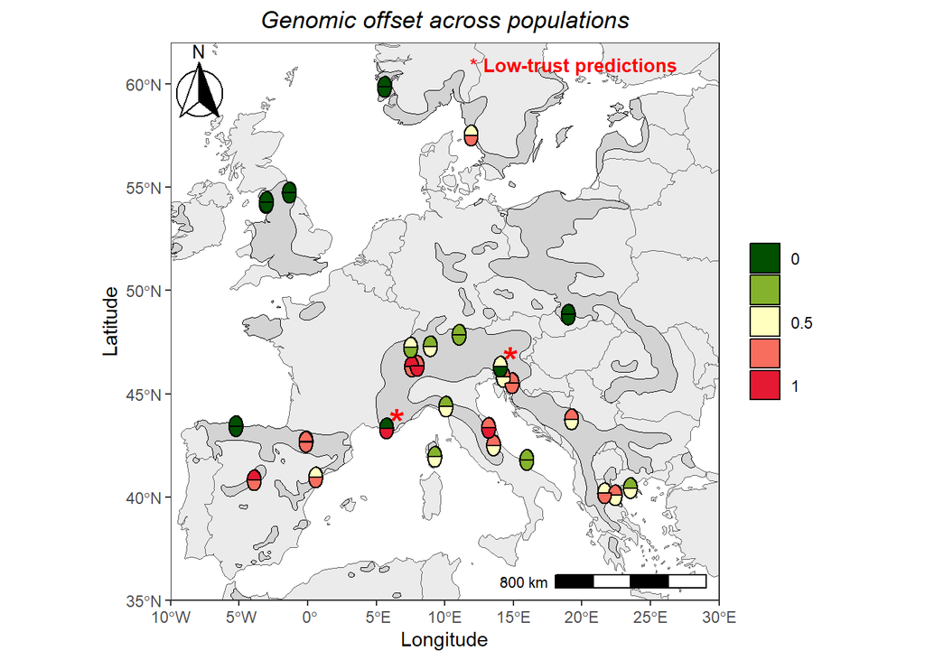

```r
colors <- c("#005000","#85B22C","#FFFFBF","#F76D5E","#E51932")

Genomic_offset_combined_all_outliers$scaled_GO_RDA <- (Genomic_offset_combined_all_outliers$GO_RDA-min(Genomic_offset_combined_all_outliers$GO_RDA))/(max(Genomic_offset_combined_all_outliers$GO_RDA)-min(Genomic_offset_combined_all_outliers$GO_RDA))

  Genomic_offset_combined_all_outliers$scaled_GO_GF <- (Genomic_offset_combined_all_outliers$GO_GF-min(Genomic_offset_combined_all_outliers$GO_GF))/(max(Genomic_offset_combined_all_outliers$GO_GF)-min(Genomic_offset_combined_all_outliers$GO_GF))

plot <- ggplot(data = Genomic_offset_combined_all_outliers) +
  geom_sf(data = admin, fill = gray(0.92), size = 0) +
  geom_sf(data = admin, fill = NA, size = 0.1) +
  geom_sf(data = shapefile, fill = "lightgrey", color = "black", size = 0.2) +  # Adding shapefile
  coord_sf(xlim = c(-10, 30), ylim = c(35, 62), expand = FALSE) +
  # Plot half-circles as usual for the genomic offsets
  geom_arc_bar(aes(
    x0 = Longitude, y0 = Latitude, r0 = 0, r = 0.5,
    start = -pi/2, end = pi/2, fill = GO_GF_interval
  ), color = "black", data = Genomic_offset_combined_all_outliers) +

  geom_arc_bar(aes(
    x0 = Longitude, y0 = Latitude, r0 = 0, r = 0.5,
    start = pi/2, end = 3 * pi/2, fill = GO_RDA_interval
  ), color = "black", data = Genomic_offset_combined_all_outliers) +

  # Add asterisk (*) slightly to the left of the circle for low-trust populations
  geom_text(
    data = Genomic_offset_combined_all_outliers %>% filter(Population %in% removed_pop),
    aes(x = Longitude + 0.75, y = Latitude+0.3, label = "*"),  # Adjust the offset value as needed
    color = "red", size = 7.5, fontface = "bold"
  ) +

  # Color scale and other plot details
  scale_fill_manual(
    name = NULL,  # Removes the legend title
    values = colors,
    labels = c("0", "", "0.5", "", "1"),
    drop = FALSE, na.translate = FALSE
  ) +
  annotate("text", x = Inf, y = Inf, label = "* Low-trust predictions",
           hjust = 1.2, vjust = 2, color = "red", size = 3.5, fontface = "bold") +
  xlab("Longitude") + ylab("Latitude") +
  ggtitle("Genomic offset across populations") +
  annotation_scale(location = "br", width_hint = 0.3) + # Scale bar at bottom left
  annotation_north_arrow(location = "tl", which_north = "true",
                         pad_x = unit(-0.2, "cm"), pad_y = unit(0.08, "cm"),
                         style = north_arrow_fancy_orienteering) + # Compass rose
  theme_bw(base_size = 11) +
  theme(
    legend.position = "right", panel.grid = element_blank(),
    strip.text = element_text(size = 11),
    plot.title = element_text(hjust = 0.5, color = "Black", face = "italic")
  )

print(plot)
```

```r
pdf("C:/Users/tfrancisco/Documents/Thesis/Results/species/taxus/Genomic_offset/Final_figures/GO_map_final_highli_bad_predict_alloutliers_newcolors.pdf");print(plot);dev.off()
```